# Tutorial 1: R talks to JavaScript

Jackson Kwok

2017-11-13

## 1.1 Basic framework

### Introduction

In this tutorial, we go through a simple example of interacting with JavaScript(JS) in R. To create an app, you will need a html file to display your app along with some JS to specify how the app behaves. And since we want to do all this in R, we also need R.

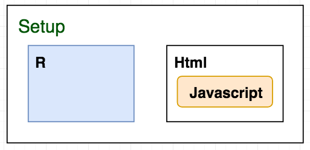

Diagram 1: JS-R app setup

Don’t worry about it if you don’t have a html file and a js file at the moment, we will build them together very soon. For now, just focus on the high-level understanding. To make R talk to JS, you need three functions:

1. `ws.send(str0)`(“ws” stands for “websocket”): this command lives in JS, and it sends a string to R every time it’s called. The common usage is `ws.send(JSON.stringify(my_complex_data))`, where we convert the (JSON) data into a string using `JSON.stringify`; this function applies to all lists in JS.
2. `ws.onmessage(msg) = function { ... }`: this function lives in JS. It continuously monitors if R has sent JS a message, and it runs the code in the body when it gets a message. The message contains many things other than your data, and we can use `JSON.parse(msg.data)` to extract the data from it.
3. Your R function (well, clearly) lives in R. It describes what R should do when JS sends R some data. The input is assumed to be a named list, and the output must also be a named list.

The following is a common pattern to use. It is very flexible; in fact, all examples in the package are created under this framework. Additional patterns can be created, but we shall leave that to another tutorial.

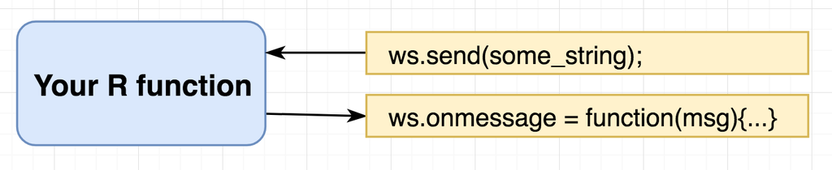

Diagram 2: JS-R communication model

### Two simple examples

#### Example 1

- JavaScript

  ```
  ws.send("hi");
  ws.onmessage = function(msg) {
    var r_data = JSON.parse(msg.data);
    console.log(r_data['r_msg']);   // this prints the message in JS console
  }
  ```

- R

  ```
  my_r_function <- function(msg) {
    print(msg)  # this will print the message in R console
    list(r_msg = msg)  # return the message to JS
  }
  ```

#### Example 2

- JavaScript

  ```
  ws.send("JSON.stringify({x:3, y:4})");    // sends a named list in JS to R
  ws.onmessage = function(msg) {
    var r_data = JSON.parse(msg.data);
    console.log(r_data['r_msg'], r_data['z']);   // this prints the message in JS console
  }
  ```

- R

  ```
  my_r_function <- function(msg) {
    print(msg)   # this will print the message in R console
    print(msg$x) # expects 3
    print(msg$y) # expects 4
    list(r_msg = msg, z = rnorm(1))  # return the message to JS
  }
  ```

## 1.2 Our first app

Now we are ready to create our first app, which looks like this:

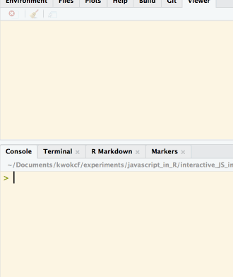

The goal is to get ourselves familiar with the JS-R communication model and the whole app development process. The full code can be found [here](https://github.com/kcf-jackson/jsReact/blob/master/inst/example.R).

### 1.2.1 App interface

First, let’s inspect the interface.

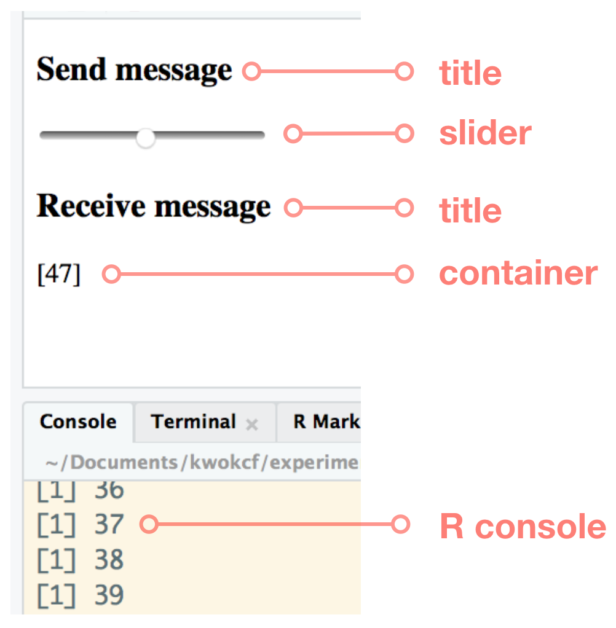

Two comments to make:

- To create a slider, you need to specify these three attributes: `min, max, oninput`. `min, max` refers to the minimum and maximum value the slider can take; `oninput` refers to a function which describes the desired behaviour when the slider is moved.
- In html, most things are just containers with different defaults. Containers are referred to as `<div>` elements.

### 1.2.2 Code

Next, let’s decompose and analyse the codes.

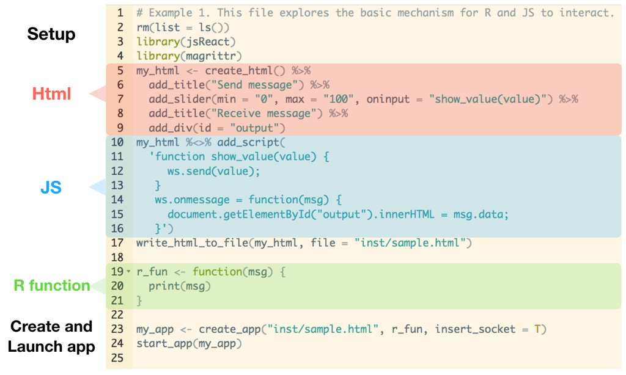

The code is divided into four sections: Html, JS, R and others. Thanks to the `jsReact` package, the code can be developed entirely in R. Though as you get more experienced and the app gets more complicated, it is preferable to create the html, js and R files separately. (Side note: this is where beginners, e.g. me, got tripped up, and this is partly why I created this package.)

#### Html

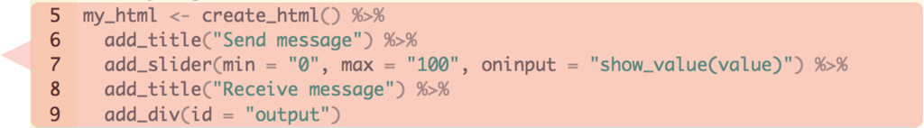

- The code is fairly self-explanatory. You create a empty html (`create_html`), add a title (`add_title`), a slider(`add_slider`) and another title, then add a container (`add_div`).
- We give the container an `id` as later we want to refer to it and update its content.

#### Javascript

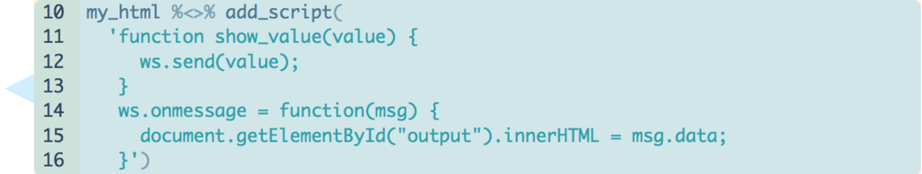

- `show_value(value)` takes the slider value and send the value to R.
- `ws.onmessage(msg)` takes a message from R and display it on the `<div>` container we created previously. `document.getElementById("_ID_")` is the easiest way to refer to a particular element in a html file. We will use that quite often.
- In JS, both `function NAME(ARG) {...}` and `NAME = function(ARG) {...}` are valid ways to create functions.

#### R function

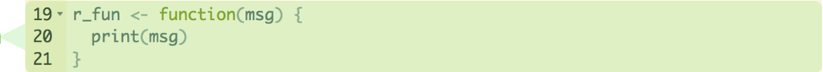

- This R function prints the message it gets from the JS side (which is the slider value in our case).

#### Others

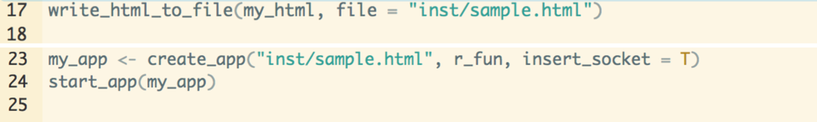

`write_html_to_file`, `create_app` and `start_app` are three functions from the `jsReact` package that helps you build and run an app.

- `write_html_to_file` writes the html object we created in the previous section to hard-drive. This is not needed if you supply your own html file.
- `create_app` links the html and the R function you provided (using the model presented in Diagram 2) and creates an app object. `insert_socket` is by default `TRUE`; you could set it to `FALSE` if you are not doing any R processing.
- `start_app` launches a R server to serve your website. By default, the address is set to “localhost:9454”, and the website is shown in your viewer. You can use the option `browser = "browser"` to open the app with your browser instead.

## 1.3 Summary

In this tutorial, we went through how to interact with JavaScript in R. The package `jsReact` setups a simple framework for this, and the three key functions to know are:

- `ws.send(str0)`, `ws.onmessage(msg)` and `your_r_function(named_list0) { named_list1 }`.

Along the way, we have also learnt about some useful functions for apps development:

- for building the html interface, we have `jsReact::add_title, jsReact::add_slider, jsReact::add_div`;
- for JavaScript, we have `document.getElementById('_ID_')`;
- for running the app, we have `jsReact::write_html_to_file(), jsReact::create_app(), jsReact::start_app()`.

I hope you successfully created an app in R, and I shall see you in the next tutorial!